# Medicare Part D Drug Spending and the Inflation Reduction Act: Analysis of First 10 Drugs Selected for Negotiation

Katherine Wei

November 2025

## Background

Spending for Medicare Part D, which is an additional benefit to fee-for-service Medicare and Medicare Advantage plans that covers prescription drugs, [doubled](https://pmc.ncbi.nlm.nih.gov/articles/PMC11607209/) from 2012 to 2021, a trend driven by both an increase in prescription claims and drug prices. In 2022, the Inflation Reduction Act (IRA) was passed by the Biden Administration to lower inflation and reduce spending in healthcare and energy. Among other changes, the [IRA](https://aspe.hhs.gov/sites/default/files/documents/0328c247692c0ccfdc58519195979af2/price-change-over-time-brief.pdf) allows Medicare to negotiate the prices of high-spending, single-source Part D drugs with no bio-similars or generics.

In August 2023, the Centers for Medicare and Medicaid Services (CMS) published the list of the 10 drugs selected for negotiation, whose new prices will take effect on January 1, 2026. They include (and [treat](https://aspe.hhs.gov/sites/default/files/documents/0328c247692c0ccfdc58519195979af2/price-change-over-time-brief.pdf)):

- Eliquis (blood clots)
- Jardiance (type 2 diabetes [T2D], heart failure, chronic kidney disease)
- Januvia (T2D)
- Farxiga (T2D, heart failure, chronic kidney disease)
- Xarelto (blood clots)
- Entresto (heart failure)
- Enbrel (rheumatoid arthritis, psoriasis, and psoriatic arthritis)
- Imbruvica (blood cancers)
- Stelara (plaque psoriasis, psoriatic arthritis, Crohn’s disease and ulcerative colitis)
- NovoLog/Fiasp (Type 1 and 2 diabetes)

In January 2025, CMS selected [15 additional drugs](https://www.cms.gov/newsroom/press-releases/hhs-announces-15-additional-drugs-selected-medicare-drug-price-negotiations-continued-effort-lower) for negotiation, a list that notably included Ozempic, Wegovy, and Rybelsus, drugs used to treat T2D. New prices will take effect starting [January 1, 2027](https://www.kff.org/medicare/faqs-about-the-inflation-reduction-acts-medicare-drug-price-negotiation-program/?entry=table-of-contents-how-many-and-which-types-of-drugs-qualified-for-price-negotiation-for-2027).

## Objective

The purpose of this brief is to analyze spending trends for the first 10 drugs selected for negotiation under the IRA, whose new prices will take effect at the beginning of next year, and how those trends compare to the top-spending drugs.

## Methods

For this analysis, data was taken from CMS’ Medicare Part D by Drug dataset (accessed October 1, 2025), which includes gross spending data on drugs covered by Medicare Part D from 2019 to 2023, excluding rebates or manufacturer discounts. The original dataset, which contained 3,598 drugs, was aggregated to combine different formulations and dosages of drugs with the same brand name. For example, Humira includes: Humira; Humira Pen; Humira Pen Crohn’S-Uc-Hs; Humira Pen Psor-Uveits-Adol Hs; Humira(Cf); Humira(Cf) Pediatric Crohn’S; Humira(Cf) Pen; Humira(Cf) Pen Crohn’S-Uc-Hs and Humira(Cf) Pen Psor-Uv-Adol Hs. This resulted in a dataset of 2,670 unique brand drugs.

The lists of drugs selected for negotiation were taken from CMS’ press releases published on their website:

- First cycle of negotiation: press release
- Second cycle of negotiation: [press release](https://www.cms.gov/newsroom/press-releases/hhs-announces-15-additional-drugs-selected-medicare-drug-price-negotiations-continued-effort-lower)

Notably, KFF did an analysis in 2023 on the same Medicare Part D Drug Spending Dataset (using 2018-2021 data) before the initial list of 10 drugs was published. Their analysis can be found [here](https://www.kff.org/medicare/a-small-number-of-drugs-account-for-a-large-share-of-medicare-part-d-spending/).

## Results

### Negotiated drugs account for 20% of total spending, share of gross spending is concentrated in a small number of drugs

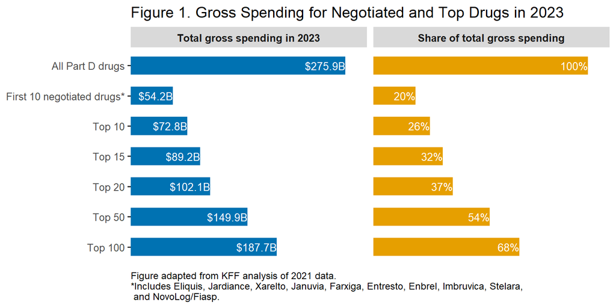

### Negotiated drugs are in the top 20 drugs by spending

**Figure 2** shows the top 20 drugs by gross spending in 2023. Gross spending across all 20 drugs totaled $102.1B or 37% of all Part D spending. The mean average spending per beneficiary was $6,139 and the mean average per claim was $1,262.

Among the 10 negotiated drugs, spending in 2023 ranged from $18.3B (6.6% of total Part D spending) for Eliquist to $2.4B (0.9%) for Imbruvica. Average spending per claim ranged from $25,521.74 (Stelara) to $862.14 (Eliquis). Average spending per beneficiary ranged from $138,707.21 (Imbruvica) to $3,145.00 (Novlog/Fiasp).

Eliquis stands out among the group, accounting for around twice the spending of the second-place drug, Jardiance. The high cost is attributable to the high number of beneficiaries and claims. In 2023, Medicare reimbursed Eliquis for almost 4 million beneficiaries across 21 million claims, double that of Jardiance (1.9 million and 8.2 million, respectively), and around 5 times the mean average across the top 20 drugs (831,000 and 4 million, respectively). However, average spending per beneficiary ($4652.28) and per claim ($862.14) were below the mean average across the top 20 drugs.

On the other hand, Imbruvica only accounted for 17,000 beneficiaries across 150,000 claims; however, the average spending was $139,000 per beneficiary (22 times the average) and $15,200 per claim (12 times the average).

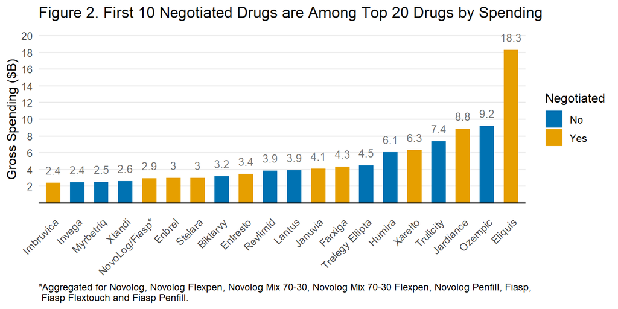

### Negotiated drugs fall into two groups: high per-patient cost or high volume

**Figure 3** plots the average gross spending per beneficiary and number of beneficiaries on a log scale for all drugs with over 10,000 beneficiaries. Overall, there is a modest negative relationship: drugs used by more beneficiaries tend to have lower average spending per patient.

Compared with non-negotiated drugs, the ten drugs selected for negotiation generally have higher spending per beneficiary relative to other drugs with similar patient volumes. These negotiated drugs cluster into two groups:

- High-cost, low-volume drugs such as Imbruvica, Enbrel, and Stelara, which treat relatively rare but expensive conditions (e.g., cancer, arthritis, psoriasis).
- Lower-cost, high-volume drugs such as Eliquis, Jardiance, Januvia, Farxiga, Xarelto, Entresto, and NovoLog/Fiasp, which treat common chronic diseases like cardiovascular disease, diabetes, and kidney disease.

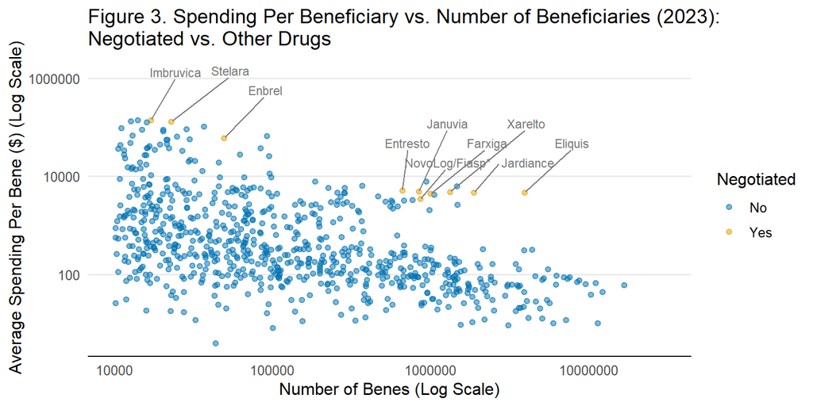

### Differences in spending per beneficiary and per claim between negotiated drugs and other drugs are growing over time

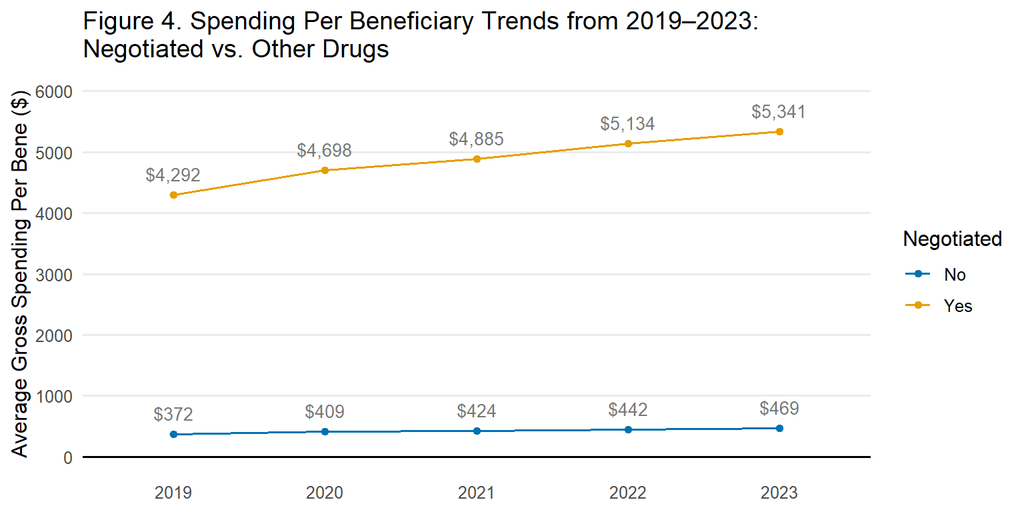

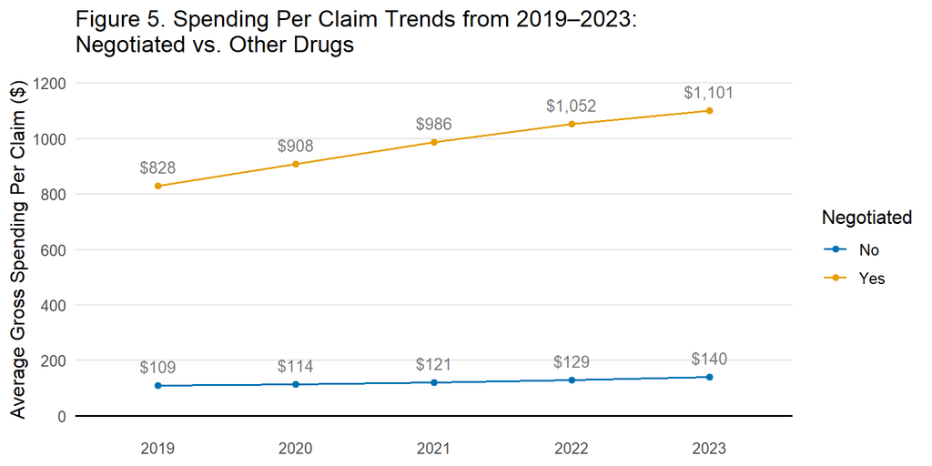

## Discussion

Overall, the data shows that the top 3% of drugs account for the majority of spending on Medicare Part D drugs. Efforts to curtail spending and lower prescription drug prices should be targeted at the top-spending drugs. The impacts of the IRA will need to be evaluated after the negotiated prices on the first 10 drugs (and subsequent sets of drugs in the following years) come into effect starting next year. The initial [price discounts](https://www.cms.gov/files/document/infographic-negotiated-prices-maximum-fair-prices.pdf), which range from 38% (Imbruvica) to 79% (Januvia), will likely result in substantial cost savings.

There are some limitations to the ability for Medicare to lower costs. Many top spending drugs not on CMS’ lists, including Humira, Lantus and Revlimid, are not eligible for negotiation due to availability of biosimilars or generics. This excludes a list of drugs responsible for a substantial portion of Part D spending. Additionally, the new [tax and budget reconciliation law](https://www.kff.org/medicare/people-with-medicare-will-face-higher-costs-for-some-orphan-drugs-due-to-changes-in-the-new-tax-and-budget-law/) also known as the One Big Beautiful Bill, which broadened the exclusion criteria of orphan drugs from negotiation, will result in delayed eligibility or exclusion for several high-spending drugs and is estimated to cost Medicare an additional $5B in the next decade.

### Limitations

There are some limitations to this analysis including:

- Data only takes into account gross spending, and does not reflect any discounts or rebates that Medicare may receive.
- The 15 drugs approved for negotiation in the second cycle are not included. A future analysis on spending trends can look at how these 15 drugs compare to the drugs not selected for negotiation.
- In looking at the IRA, only Medicare Part D data was analyzed. Drugs covered under Part B are also eligible for negotiation under the new act.